# Caractérisation de l’environnement autour des piqûres de tiques

Analyse spatiale par données de couverture terrestre CLC+

Author

Eric Delmelle (pour Paris8)

Published

October 20, 2025

# 1 Introduction

Ce document présente une méthodologie d’analyse de l’environnement autour de sites d’intérêt (ici, des lieux de piqûres de tiques potentielles) en utilisant les données de couverture terrestre **CLC+ Backbone 2018** à résolution 10 m.

# 2 Configuration

## 2.1 Packages requis

```r
# auto-installation si besoin
pkgs <- c("sf","terra","exactextractr","dplyr","tidyr","ggplot2","compositions","tmap")
to_install <- setdiff(pkgs, rownames(installed.packages()))
if (length(to_install)) install.packages(to_install, repos="https://cloud.r-project.org")

# charge paquets
lapply(c("sf","terra","dplyr","tidyr","ggplot2","compositions","tmap"), library, character.only = TRUE)
```

[output not shown]

```r
# drapeau pour l’extraction exacte pondérée
has_exact <- requireNamespace("exactextractr", quietly = TRUE)
if (has_exact) library(exactextractr)
```

## 2.2 Chargement du raster CLC+

Le raster est en **EPSG:3035** (LAEA Europe). Si la projection n’est pas lue correctement, on l’assigne explicitement.

```r
# Chemin vers le raster
raster_path <- "CLCplus_2018_010m.tif"
raster_clc <- rast(raster_path)

# Définition WKT pour EPSG:3035 si nécessaire
wkt3035 <- 'PROJCRS["ETRS89-extended / LAEA Europe",
 BASEGEOGCRS["ETRS89",
   DATUM["European Terrestrial Reference System 1989",
     ELLIPSOID["GRS 1980",6378137,298.257222101]],
   PRIMEM["Greenwich",0]],
 CONVERSION["Lambert Azimuthal Equal Area",
   METHOD["Lambert Azimuthal Equal Area"],
   PARAMETER["Latitude of natural origin",52],
   PARAMETER["Longitude of natural origin",10],
   PARAMETER["False easting",4321000],
   PARAMETER["False northing",3210000]],
 CS[Cartesian,2],
   AXIS["easting (X)",east],
   AXIS["northing (Y)",north],
   LENGTHUNIT["metre",1],
 ID["EPSG",3035]]'

if (is.na(crs(raster_clc)) || crs(raster_clc) == "") {
  crs(raster_clc) <- wkt3035
}

# Vérifications
cat("Résolution:", res(raster_clc), "m\n")
```

```
Résolution: 10 10 m
```

```r
cat("Projection:", as.character(crs(raster_clc, proj = TRUE)), "\n")
```

```
Projection: +proj=laea +lat_0=52 +lon_0=10 +x_0=4321000 +y_0=3210000 +ellps=GRS80 +units=m +no_defs
```

# 3 Sites d’intérêt

Trois sites en région parisienne, avec coordonnées géographiques (WGS84) :

```r
sites <- tibble::tribble(
  ~site,                      ~lon,       ~lat,
  "Orly – pistes",            2.3658,     48.7283,
  "Forêt de Fontainebleau",   2.6667,     48.4167,
  "Étampes – plaine agricole",2.1615,     48.4343
)

knitr::kable(sites, caption = "Coordonnées des sites d'étude")
```

Coordonnées des sites d’étude

| site | lon | lat |
| --- | --- | --- |
| Orly – pistes | 2.3658 | 48.7283 |
| Forêt de Fontainebleau | 2.6667 | 48.4167 |
| Étampes – plaine agricole | 2.1615 | 48.4343 |

# 4 Fonctions utilitaires

## 4.1 Mapping des classes CLC+ vers familles

Le **CLC+ Backbone** contient 11 classes principales (1–11). On les regroupe en 4 familles :

- **Urbain** : classe 1 (surfaces scellées)
- **Forêt** : classes 2–4 (arbres)
- **Agricole** :
  - Mode `"strict"` : classe 7 uniquement (cultures périodiques)
  - Mode `"large"` : classes 6–7 (herbacées permanentes + cultures)
- **Autres** : tout le reste (5, 8–11)

```r
map_famille <- function(valeur_pixel, mode_agricole = c("strict", "large")) {
  mode_agricole <- match.arg(mode_agricole)
  if (valeur_pixel == 1) return("urbain")
  if (valeur_pixel %in% c(2,3,4)) return("foret")
  if (mode_agricole == "strict" && valeur_pixel %in% 7) return("agricole")
  if (mode_agricole == "large"  && valeur_pixel %in% c(6,7)) return("agricole")
  return("autres")
}

.extract_weighted_table <- function(geom_input, raster_input, mode_agricole = "strict", mapping_list = NULL){
  # sortie: data.frame(famille, weight)
  if (exists("has_exact") && isTRUE(has_exact)) {
    # exact (pondéré par fraction de couverture)
    out <- exactextractr::exact_extract(
      raster_input, geom_input,
      fun = function(values, coverage_fractions){
        df <- data.frame(val = values, w = coverage_fractions)
        df <- df[!is.na(df$val) & df$val %in% 1:11, ]
        if (is.null(mapping_list)) {
          df$famille <- vapply(df$val, function(x) map_famille(x, mode_agricole), character(1))
        } else {
          df$famille <- "autres"
          for (nm in names(mapping_list)) df$famille[df$val %in% mapping_list[[nm]]] <- nm
        }
        aggregate(w ~ famille, df, sum)
      }
    )[[1]]
    names(out) <- c("famille","weight")
    return(out)
  } else {
    # fallback approx: cellules entièrement dans le polygone (pas de pondération de bord)
    g <- terra::vect(sf::st_as_sf(geom_input))
    r_crop <- terra::crop(raster_input, g)
    r_mask <- terra::mask(r_crop, g)
    tab <- as.data.frame(terra::freq(r_mask, useNA="no"))
    if (is.null(tab) || !nrow(tab)) return(data.frame(famille=character(0), weight=numeric(0)))
    tab <- tab[tab$value %in% 1:11, c("value","count")]
    if (is.null(mapping_list)) {
      tab$famille <- vapply(tab$value, function(x) map_famille(x, mode_agricole), character(1))
    } else {
      tab$famille <- "autres"
      for (nm in names(mapping_list)) tab$famille[tab$value %in% mapping_list[[nm]]] <- nm
    }
    aggregate(count ~ famille, tab, sum) |>
      stats::setNames(c("famille","weight"))
  }
}

extract_pct <- function(geom_input, raster_input, mode_agricole = "strict"){
  agg <- .extract_weighted_table(geom_input, raster_input, mode_agricole = mode_agricole)
  if (!nrow(agg)) return(data.frame(urbain=0, agricole=0, foret=0, autres=0))
  total <- sum(agg$weight)
  labs <- c("urbain","agricole","foret","autres")
  res <- setNames(numeric(4), labs)
  for (nm in labs) if (nm %in% agg$famille) res[nm] <- 100 * agg$weight[agg$famille==nm] / total
  as.data.frame(as.list(res))
}

extract_pct_map <- function(geom_input, raster_input, mapping_list){
  agg <- .extract_weighted_table(geom_input, raster_input, mapping_list = mapping_list)
  if (!nrow(agg)) return(as.data.frame(as.list(setNames(rep(0, length(mapping_list)), names(mapping_list)))))
  total <- sum(agg$weight)
  res <- setNames(numeric(length(mapping_list)), names(mapping_list))
  for (nm in names(mapping_list)) if (nm %in% agg$famille) res[nm] <- 100 * agg$weight[agg$famille==nm] / total
  as.data.frame(as.list(res))
}
```

## 4.2 Extraction pondérée par surface

Fonction générique pour extraire les pourcentages de chaque famille dans une géométrie donnée :

```r
extract_pct <- function(geom_input, raster_input, mode_agricole = "strict") {
  exactextractr::exact_extract(
    raster_input, geom_input,
    fun = function(values, coverage_fractions) {
      data_temp <- data.frame(val = values, weight = coverage_fractions)
      # Garder seulement classes 1–11 (exclut 253/254/255)
      data_temp <- data_temp[!is.na(data_temp$val) & data_temp$val %in% 1:11, ]

      if (nrow(data_temp) == 0) {
        return(data.frame(urbain = 0, agricole = 0, foret = 0, autres = 0))
      }

      data_temp$famille <- vapply(
        data_temp$val,
        function(x) map_famille(x, mode_agricole),
        character(1)
      )

      aggregated <- aggregate(weight ~ famille, data_temp, sum)
      total_weight <- sum(aggregated$weight)

      output_names <- c("urbain", "agricole", "foret", "autres")
      output_values <- setNames(numeric(length(output_names)), output_names)

      for (nom_famille in output_names) {
        if (nom_famille %in% aggregated$famille) {
          output_values[nom_famille] <- 100 * aggregated$weight[aggregated$famille == nom_famille] / total_weight
        }
      }

      as.data.frame(as.list(output_values))
    }
  )
}
```

## 4.3 Extraction avec mapping personnalisé

Pour les études de sensibilité, une fonction qui accepte des mappings personnalisés :

```r
extract_pct_map <- function(geom_input, raster_input, mapping_list) {
  exactextractr::exact_extract(raster_input, geom_input, fun = function(values, weights) {
    data_temp <- data.frame(val = values, weight = weights)
    data_temp <- data_temp[!is.na(data_temp$val) & data_temp$val %in% 1:11, ]

    if (!nrow(data_temp)) {
      return(as.data.frame(setNames(as.list(rep(0, length(mapping_list))), names(mapping_list))))
    }

    famille_vec <- rep("autres", nrow(data_temp))
    for (nom_famille in names(mapping_list)) {
      famille_vec[data_temp$val %in% mapping_list[[nom_famille]]] <- nom_famille
    }
    data_temp$famille <- famille_vec

    aggregated <- aggregate(weight ~ famille, data_temp, sum)
    total_weight <- sum(aggregated$weight)

    output_values <- setNames(numeric(length(mapping_list)), names(mapping_list))
    for (nom_famille in names(mapping_list)) {
      if (nom_famille %in% aggregated$famille) {
        output_values[nom_famille] <- 100 * aggregated$weight[aggregated$famille == nom_famille] / total_weight
      }
    }

    as.data.frame(as.list(output_values))
  })
}
```

# 5 Analyse multi-sites

On calcule les proportions de couverture dans des **buffers de 1 km** et deux **anneaux** (0–300 m, 300–1000 m).

```r
rayon_principal <- 1000
limites_anneaux <- c(0, 300, 1000)

liste_resultats_sites <- list()

for (index_site in seq_len(nrow(sites))) {
  # Point en EPSG:3035
  point_site <- st_sfc(
    st_point(c(sites$lon[index_site], sites$lat[index_site])),
    crs = 4326
  ) |> st_transform(3035)

  # Buffer complet 0–1000 m
  buffer_complet <- st_buffer(point_site, rayon_principal) |>
                    st_transform(crs(raster_clc))

  pourcentages_buffer <- extract_pct(buffer_complet, raster_clc)

  resultat_buffer <- cbind(
    site = sites$site[index_site],
    zone = "0-1000m",
    round(pourcentages_buffer, 1)
  )

  # Anneaux
  anneau_1 <- st_difference(
    st_buffer(point_site, limites_anneaux[2]),
    st_buffer(point_site, limites_anneaux[1])
  ) |> st_transform(crs(raster_clc))

  anneau_2 <- st_difference(
    st_buffer(point_site, limites_anneaux[3]),
    st_buffer(point_site, limites_anneaux[2])
  ) |> st_transform(crs(raster_clc))

  pourcentages_anneau1 <- extract_pct(anneau_1, raster_clc)
  pourcentages_anneau2 <- extract_pct(anneau_2, raster_clc)

  resultat_anneaux <- rbind(
    cbind(site = sites$site[index_site], zone = "0-300m", round(pourcentages_anneau1, 1)),
    cbind(site = sites$site[index_site], zone = "300-1000m", round(pourcentages_anneau2, 1))
  )

  liste_resultats_sites[[index_site]] <- rbind(resultat_buffer, resultat_anneaux)
}

resultats_finaux <- do.call(rbind, liste_resultats_sites)
knitr::kable(resultats_finaux, caption = "Composition de l'occupation du sol par site et zone")
```

Composition de l’occupation du sol par site et zone

| site | zone | urbain | agricole | foret | autres |
| --- | --- | --- | --- | --- | --- |
| Orly – pistes | 0-1000m | 76.6 | 1.3 | 0.3 | 21.9 |
| Orly – pistes | 0-300m | 97.3 | 0.1 | 0.0 | 2.6 |
| Orly – pistes | 300-1000m | 74.5 | 1.4 | 0.3 | 23.8 |
| Forêt de Fontainebleau | 0-1000m | 0.8 | 0.1 | 98.2 | 1.0 |
| Forêt de Fontainebleau | 0-300m | 0.0 | 0.0 | 100.0 | 0.0 |
| Forêt de Fontainebleau | 300-1000m | 0.9 | 0.1 | 98.0 | 1.1 |
| Étampes – plaine agricole | 0-1000m | 56.9 | 0.5 | 21.0 | 21.6 |
| Étampes – plaine agricole | 0-300m | 88.1 | 0.0 | 7.8 | 4.1 |
| Étampes – plaine agricole | 300-1000m | 53.8 | 0.6 | 22.3 | 23.4 |

## 5.1 Visualisation comparative

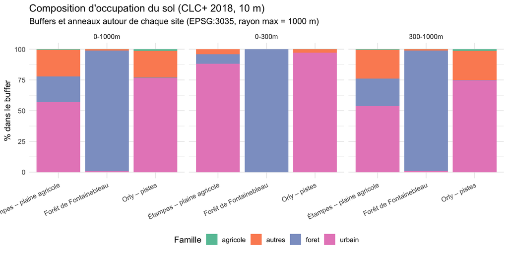

```r
resultats_long <- resultats_finaux |>
  pivot_longer(
    cols = c(urbain, agricole, foret, autres),
    names_to = "famille",
    values_to = "pct"
  )

ggplot(resultats_long, aes(x = site, y = pct, fill = famille)) +
  geom_col() +
  facet_wrap(~zone, nrow = 1) +
  scale_fill_brewer(palette = "Set2") +
  labs(
    x = NULL,
    y = "% dans le buffer",
    fill = "Famille",
    title = "Composition d'occupation du sol (CLC+ 2018, 10 m)",
    subtitle = paste0("Buffers et anneaux autour de chaque site (EPSG:3035, rayon max = ", rayon_principal, " m)")
  ) +
  theme_minimal(base_size = 12) +
  theme(
    axis.text.x = element_text(angle = 25, hjust = 1),
    legend.position = "bottom"
  )
```

# 6 Études de sensibilité

## 6.1 A) Granularité spatiale

Sensibilité des proportions au **rayon du buffer**.

```r
# Paramètres
serie_rayons <- c(300, 500, 750, 1000, 1500)

# Point de référence : Orly
point_orly_granul <- st_sfc(st_point(c(2.3658, 48.7283)), crs = 4326) |>
                     st_transform(3035)

# Calcul pour chaque rayon avec une boucle FOR explicite
liste_granularite <- list()

for (index_rayon in seq_along(serie_rayons)) {
  rayon_metres <- serie_rayons[index_rayon]

  # Créer le buffer en EPSG:3035 puis transformer vers CRS du raster
  buffer_temp <- st_buffer(point_orly_granul, rayon_metres) |>
                 st_transform(crs(raster_clc))

  # Extraire les proportions
  proportions_temp <- extract_pct(buffer_temp, raster_clc, mode_agricole = "strict")
  proportions_temp$rayon_m <- rayon_metres

  # Stocker dans la liste
  liste_granularite[[index_rayon]] <- proportions_temp
}

# Combiner tous les résultats
resultats_granularite <- dplyr::bind_rows(liste_granularite) |>
  dplyr::relocate(rayon_m)

knitr::kable(resultats_granularite, digits = 1, caption = "Proportions selon le rayon du buffer")
```

Proportions selon le rayon du buffer

| rayon_m | urbain | agricole | foret | autres |
| --- | --- | --- | --- | --- |
| 300 | 97.3 | 0.1 | 0.0 | 2.6 |
| 500 | 93.2 | 0.1 | 0.2 | 6.5 |
| 750 | 89.5 | 0.3 | 0.2 | 9.9 |
| 1000 | 76.6 | 1.3 | 0.3 | 21.9 |
| 1500 | 58.4 | 1.7 | 0.9 | 38.9 |

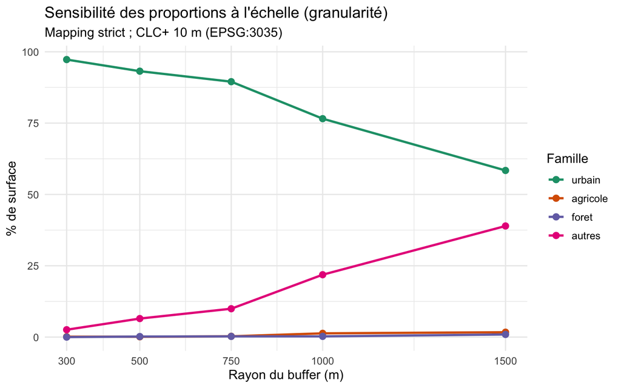

```r
resultats_granularite |>
  tidyr::pivot_longer(
    cols = c(urbain, agricole, foret, autres),
    names_to = "famille",
    values_to = "pct"
  ) |>
  dplyr::mutate(famille = factor(famille, levels = c("urbain", "agricole", "foret", "autres"))) |>
  ggplot(aes(rayon_m, pct, color = famille)) +
  geom_line(linewidth = 1) +
  geom_point(size = 2.5) +
  scale_x_continuous(breaks = serie_rayons) +
  scale_color_brewer(palette = "Dark2") +
  labs(
    x = "Rayon du buffer (m)",
    y = "% de surface",
    color = "Famille",
    title = "Sensibilité des proportions à l'échelle (granularité)",
    subtitle = "Mapping strict ; CLC+ 10 m (EPSG:3035)"
  ) +
  theme_minimal(base_size = 12) +
  theme(legend.position = "right")
```

## 6.2 B) Traitement compositionnel

Les proportions forment une **composition** (somme = 100%). Pour les analyser correctement en statistiques multivariées, on utilise la transformation **CLR** (Centered Log Ratio).

**Problème** : `log(0)` → `-Inf`.

**Solution** : ajouter un pseudo-compte epsilon (ex: 10⁻⁶) aux zéros uniquement, puis re-normaliser.

```r
# Exemple : plus petit rayon
proportions_min <- resultats_granularite |>
  dplyr::filter(rayon_m == min(serie_rayons)) |>
  dplyr::select(urbain, agricole, foret)

proportions_vec <- as.numeric(proportions_min[1, ]) / 100
names(proportions_vec) <- c("urbain", "agricole", "foret")

# Ajout epsilon sur les zéros
epsilon_value <- 1e-6
proportions_eps <- proportions_vec
proportions_eps[proportions_eps == 0] <- epsilon_value
proportions_eps <- proportions_eps / sum(proportions_eps)

# Transformation CLR
valeurs_clr <- clr(acomp(proportions_eps))

tableau_clr <- data.frame(
  famille = names(proportions_vec),
  proportion = proportions_vec,
  proportion_eps = proportions_eps,
  clr = as.numeric(valeurs_clr)
)

knitr::kable(tableau_clr, digits = 6, caption = "Transformation CLR robuste aux zéros")
```

Transformation CLR robuste aux zéros

|  | famille | proportion | proportion_eps | clr |
| --- | --- | --- | --- | --- |
| urbain | urbain | 0.972751 | 0.998546 | 6.773543 |
| agricole | agricole | 0.001415 | 0.001453 | 0.240797 |
| foret | foret | 0.000000 | 0.000001 | -7.014340 |

**Important**

Les valeurs CLR somment à zéro par construction. Elles permettent d’appliquer des analyses statistiques classiques (ACP, régression) sur des données compositionnelles.

# 7 Visualisation cartographique détaillée

Cette section présente une cartographie détaillée avec plusieurs cercles de distance pour visualiser les gradients de composition paysagère.

## 7.1 Préparation des géométries

```r
# Paramètres pour la carte détaillée
serie_rayons_carte <- c(100, 300, 1000, 1500, 2000)

# Point de référence : Orly
point_orly_carte <- st_sfc(st_point(c(2.3658, 48.7283)), crs = 4326) |>
                    st_transform(3035)

# Cercles concentriques (disques 0–R)
liste_cercles <- list()
for (numero_cercle in seq_along(serie_rayons_carte)) {
  liste_cercles[[numero_cercle]] <- st_buffer(
    point_orly_carte,
    serie_rayons_carte[numero_cercle]
  )[[1]]
}

cercles_sf <- st_sf(
  rayon = serie_rayons_carte,
  geometry = st_sfc(liste_cercles, crs = 3035)
) |> st_transform(crs(raster_clc))

# Anneaux successifs (R_{i-1}–R_i)
rayons_debut <- c(0, head(serie_rayons_carte, -1))
rayons_fin <- serie_rayons_carte

liste_anneaux_carte <- list()
for (numero_anneau in seq_along(serie_rayons_carte)) {
  anneau_geom <- st_difference(
    st_buffer(point_orly_carte, rayons_fin[numero_anneau]),
    st_buffer(point_orly_carte, rayons_debut[numero_anneau])
  )[[1]] |> st_make_valid()

  liste_anneaux_carte[[numero_anneau]] <- anneau_geom
}

anneaux_sf <- st_sf(
  ring = sprintf("%d–%dm", rayons_debut, rayons_fin),
  geometry = st_sfc(liste_anneaux_carte, crs = 3035)
) |>
  st_transform(crs(raster_clc)) |>
  dplyr::filter(!st_is_empty(geometry))
```

## 7.2 Carte avec cercles de distance

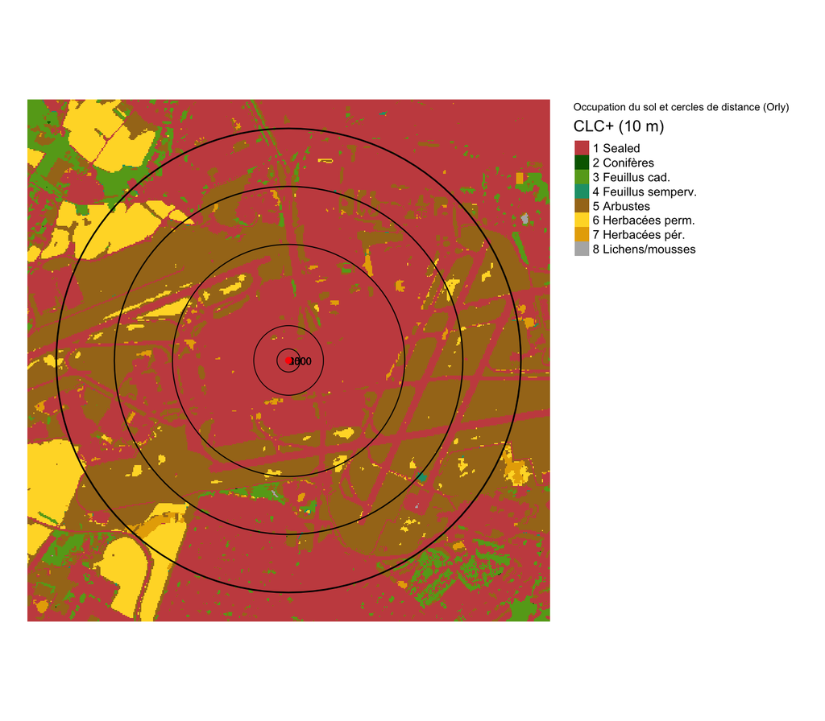

```r
# Légende CLC+ Backbone (11 classes)
etiquettes_clc <- c(
  "1 Sealed", "2 Conifères", "3 Feuillus cad.", "4 Feuillus semperv.",
  "5 Arbustes", "6 Herbacées perm.", "7 Herbacées pér.",
  "8 Lichens/mousses", "9 Sols nus", "10 Eau", "11 Neige/Glace"
)
palette_clc <- c(
  "#c84f4f", "#006400", "#66a61e", "#1b9e77",
  "#a6761d", "#ffd92f", "#e6ab02",
  "#b3b3b3", "#d9d9d9", "#1f78b4", "#a6cee3"
)

# Recadrage du raster autour de la zone d'intérêt
boite_englobante <- st_buffer(point_orly_carte, max(serie_rayons_carte) + 250) |>
                    st_transform(crs(raster_clc))
raster_recadre <- terra::crop(raster_clc, terra::vect(boite_englobante))

# Création de la carte
tmap_mode("plot")
tm_shape(raster_recadre) +
  tm_raster(
    style = "cat",
    palette = palette_clc,
    labels = etiquettes_clc,
    title = "CLC+ (10 m)"
  ) +
  tm_shape(cercles_sf) +
  tm_borders(col = "black", lwd = c(0.8, 0.8, 1, 1.2, 1.5)) +
  tm_text("rayon", just = "left", xmod = 0.01, ymod = -0.01, size = 0.6) +
  tm_shape(st_transform(point_orly_carte, crs(raster_clc))) +
  tm_symbols(col = "red", size = 0.15, shape = 19) +
  tm_layout(
    legend.outside = TRUE,
    frame = FALSE,
    title = "Occupation du sol et cercles de distance (Orly)",
    title.size = 1,
    legend.text.size = 0.7
  )
```